# Proportion Problems and Chi-Squared Tests

Stanford University, Spring 2016, STATS 205

## Previous Lectures

- One-sample tests:
  - Sign test
  - Signed-Rank Wilcoxon
- Estimators, confidence intervals, and robustness to outliers
- Bootstrap
  - Error of estimators and significance for hypothesis testing
  - Complete enumerations
  - Tail probability
- Observations from continuous distributions

## Today

- Observations from discrete distributions
- Proportion problems
- \(\chi^2\) Tests

## Proportion Problems

- Discrete variables
- The random variable \(X\) consists of categories
- For now, we focus on binary categories failure (0) and success (1)
- \(X\) is a random variable distributed according to the Bernoulli distribution
  - with success probabiliy \(p\) and
  - failure probabililty \(1-p\)
- We know that \(\operatorname{E}(X) = p\) and \(\operatorname{Var} = p(1-p)\)

## Proportion Problems

- Statistical problems can be
  - estimating \(p\)
  - forming confidence intervals around estimate \(\widehat{p}\)
  - and testing hypothesis \[H_0: p = p_0 \text{ versus } H_A: p \ne p_0\]
- Let \(X_1,\dots,X_n\) iid Bernoulli with success probability \(p\) and \(S\) be the total number of successes
- Then \(S\) follows a binomial distribution with \(n\) trials and success probability \(p\)
- If \(p\) is unkown, we estimate \(p\) with \(\widehat{p} = \frac{S}{n}\)

## Proportion Problems

```r
n = 10; p = 1/2; nsim = 10000; obsv = rbinom(nsim, size = n, prob = p)
```

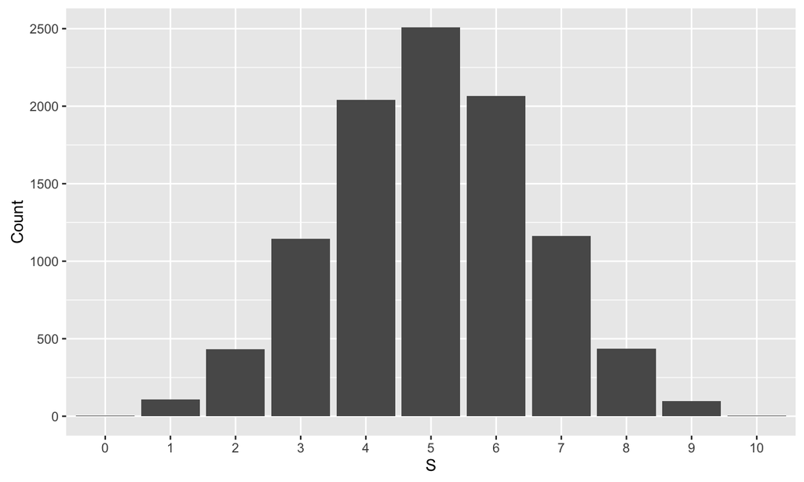

## Proportion Problems

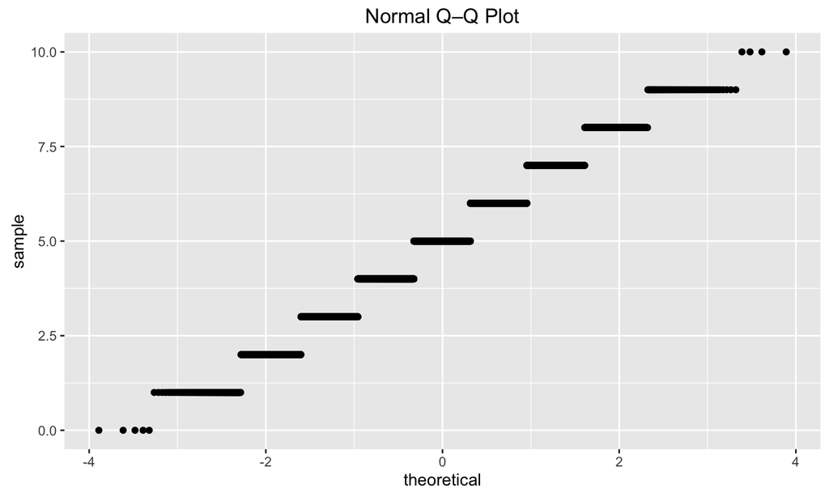

## Proportion Problems

```r
n = 100; p = 1/2; nsim = 10000; obsv = rbinom(nsim, size = n, prob = p)
```

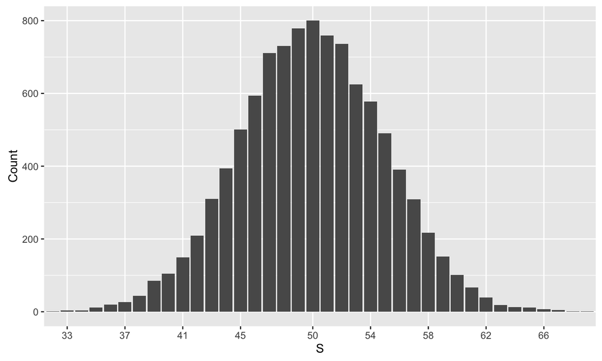

## Proportion Problems

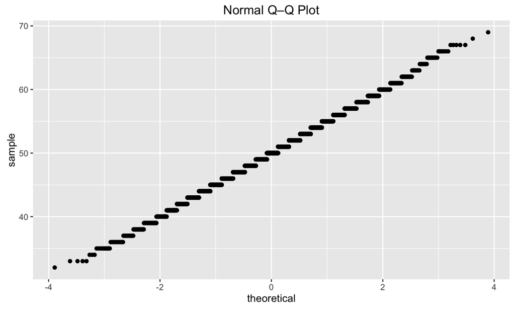

## Proportion Problems

- As \(n \to \infty\) while \(p\) is fixed:
  - The de Moivre–Laplace theorem (a special case of the central limit theorem) says \(S\) approach a normal distribution
  - Easy confidence interval (just evaluate cdf of the normal)
  - Approximation of binomial distribution with \(n\) trials and \(p\) success by \(N(np,np(1-p))\)

## Example: Squeaky Hip Replacements

143 subjects with ceramic hip replacements

Ten report that their hip replacements squeaked

```r
phat = 10/143
phat
```

```
## [1] 0.06993007
```

```r
zcv = qnorm(0.975)
phat+c(-1,1)*zcv*sqrt(phat*(1-phat)/143)
```

```
## [1] 0.02813069 0.11172945
```

We estimate between roughly 3 and 11% of patients who receive ceramic hip replacements will report squeaky replacements

## Hypothesis Testing

- Reject null hypotheis if \(|z|\) is large \[z = \frac{\widehat{p}-p_0}{\sqrt{p_0(1-p_0)/n}} \sim N(0,1)\]
- \(z\) is asymptotically standard normal
- An equivalent test statistic of \(|z|\) is \(z^2\)
- Squared normal is distributed as \(\chi^2\) distribution

## Example: Left-Handed Professional Ball Players

- Theory:
  - Professional baseball players have different proportion of left handed player than left-handed people in genral population
  - From previous study, we know that general public is has a proportion of \(p_0 = 0.15\)
- Hypothesis testing:
  - \(H_0: p = 0.15 \text{ versus } H_A: p \ne 0.15\)

## Example: Left-Handed Professional Ball Players

```r
library(Rfit)
head(baseball)
```

```
##   height weight bat throw field average
## 1     74    218   R     L     0   3.330
## 2     75    185   R     R     1   0.286
## 3     77    219   L     L     0   3.040
## 4     73    185   R     R     1   0.271
## 5     69    160   S     R     1   0.242
## 6     73    222   R     R     0   3.920
```

## Example: Left-Handed Professional Ball Players

```r
ind = with(baseball,throw=='L')
n = length(ind)
phat = sum(ind)/n
phat
```

```
## [1] 0.2542373
```

```r
p0 = 0.15
z = (phat-p0)/(sqrt(p0*(1-p0)/n))
pvalue = 1-pchisq(z^2,df=1)
pvalue
```

```
## [1] 0.02494189
```

## What is Nonparametrics Statistics Again?

- In all three nonparametric test (sign, signed-rank, \(\chi^2\)) no assumption on variances of observations
- In contrast, in the \(t\)-test variances are estimated

## Why Not Use Finite Sample Binomial Test?

Since we know that \(S\) follows a binomial distribution, why don't we use it?

```
##
##  Exact binomial test
##
## data:  sum(ind) and n
## number of successes = 15, number of trials = 59, p-value = 0.04192
## alternative hypothesis: true probability of success is not equal to 0.15
## 95 percent confidence interval:
##  0.1498208 0.3844241
## sample estimates:
## probability of success
##              0.2542373
```

- Finite sample \(p\)-values have upper bounded significance level \(\alpha\)
- Asymptotic \(p\)-values may be above above \(\alpha\)

## Why Not Use Finite Sample Binomial Test?

Problem is due to discreteness

Example: \(n = 5\) and test \(H_0: p = 0.5\) versus \(H_A: p \ne 0.5\)

Null distribution of \(S\) is binomial with \(n = 5\) and \(p = 0.5\)

Suppose outcome is \(S = 5\) (most extreme observation)

```r
n = 5; S = 5; p = 0.5
phat = S/n
pvalue = 2*p^S; pvalue
```

```
## [1] 0.0625
```

So in this case, \(\alpha\) has no meaning

## Discrete Random Variable (RV)

- Extension from two categories to multiple caterogries
- Consider discrete RV \(X\) with \(1,2,\dots,c\) categories
- Let \(p(j) = P(X = j)\) define the probabiliy mass function
- We wish to test: \[H_0: p(j) = p_0(j), j = 1,\dots,c\] \[H_A: p(j) \ne p_0(j), \text{ for some } j\]

## Discrete RV

- \(X_1,\dots,X_n\) is a random sample on \(X\)
- Let \(O_j = \#\{ X_i = j \}\)
- Observed frequencies are constrained \(\sum_{j=1}^c O_j = n\)
- The expected frequency for category \(j\) is \(\operatorname{E}_j = \operatorname{E}_{H_0}(O_j)\)
- Two cases for \(H_0\)

## Discrete RV

- Case 1:
  - All \(p_0(j)\) are specified
  - So we get \(E_j = np_0(j)\)
  - Test stastitics is \[\chi^2 = \sum_{j=1}^c \frac{(O_j-E_j)^2}{E_j}\]
- Hypothesis \(H_0\) is rejected in favor of \(H_A\) for large values of \(\chi^2\)
- Observed frequencies, \((O_1,\dots,O_c)^T\) has a multinomial distribution, so exact distribution can be obtained
- Asymptotically \(\chi^2\) distribution with \(c−1\) degrees of freedom
- If we know \(c-1\) frequencies, we can calculate the \(c\)th from total \(n\)

## Discrete RV Example

Roll a dice \(n = 370\) times

Observe frequencies

```r
O = c(58,55,62,68,66,61)
n = sum(O); n
```

```
## [1] 370
```

Test whether dice is fair \(p(j) \equiv 1/6\)

```r
p0 = 1/6
E = rep(n*p0,6)
Chi2_0 = sum((O-E)^2/E); Chi2_0
```

```
## [1] 1.902703
```

## Discrete RV Example

Assymptotically equal to \(\chi^2\) with \(c-1\) degress of freedom

```r
pvalue = 1-pchisq(Chi2_0,df=6-1); pvalue
```

```
## [1] 0.8624375
```

Thus there is no evidence to support the dice being unfair

## Discrete RV

- Case 2:
  - Only form of pmf is known
  - Have to estimate \(p\)
  - Same test stastitics but now with estimate \(\widehat{p}\) \[\chi^2 = \sum_{j=1}^c \frac{(O_j-E_j)^2}{E_j}\]
- Hypothesis \(H_0\) is rejected in favor of \(H_A\) for large values of \(\chi^2\)

## Discrete RV Example

Number of males in the first seven children for \(n = 1334\) Swedish ministers of religion

```r
males = 0:7
ministers = c(6,57,206,362,365,256,69,13)
n = sum(ministers); n
```

```
## [1] 1334
```

```r
df = data.frame(ministers=ministers,males=males); t(df)
```

```
##           [,1] [,2] [,3] [,4] [,5] [,6] [,7] [,8]
## ministers    6   57  206  362  365  256   69   13
## males        0    1    2    3    4    5    6    7
```

For example, 206 ministers had 2 sons and 5 daughters in their first 7 children

## Discrete RV Example

The maximum likelihood estimator of \(p\) is

```r
nChildren = n*7
nMale = sum(df$ministers*df$males)
phat = nMale/nChildren; phat
```

```
## [1] 0.5140287
```

```r
p0 = dbinom(males,7,phat)
E = n*p0
```

```
##           [,1] [,2]  [,3]  [,4]  [,5]  [,6] [,7] [,8]
## E          8.5 63.2 200.6 353.7 374.1 237.4 83.7 12.6
## ministers  6.0 57.0 206.0 362.0 365.0 256.0 69.0 13.0
## males      0.0  1.0   2.0   3.0   4.0   5.0  6.0  7.0
```

## Discrete RV Example

```r
Chi2_0 = sum((df$ministers-E)^2/E)
pvalue = 1-pchisq(Chi2_0,df=8-1-1); pvalue
```

```
## [1] 0.4257546
```

No evidence to refute a binomial probability model for the number of sons in the first seven children of a Swedish minister

## Discrete RV

- Alternatively to testing for deviation from a model
- We can get a confidence interval on pairwise difference in proportions \(\widehat{p}_j - \widehat{p}_k\)
- The confidence intervals are easy again because, we assume asymptotic normallity

## Discrete RV Example

Difference in the probabilities of all daughters or all sons

```
##           [,1] [,2] [,3] [,4] [,5] [,6] [,7] [,8]
## ministers    6   57  206  362  365  256   69   13
## males        0    1    2    3    4    5    6    7
```

6 ministers had no sons, and 13 ministers had all sons

```r
n = 1334; p0 = 6/n; p7 = 13/n
se = sqrt((p0+p7-(p0-p7)^2)/n)
zcv = qnorm(0.975)
lb = p0-p7 - zcv*se; ub = p0-p7 + zcv*se; res = c(p0-p7,lb,ub); res
```

```
## [1] -0.005247376 -0.011645444  0.001150692
```

Confidence interval covers 0, thus no significant difference in the proportions

## Several Discrete RVs

- Goal is to compare several discrete RV, which have same range \(\{ 1,2,\dots,c \}\)
- Consider hypothesis test:
  - \(H_0:\) \(X_1,\dots,X_r\) have the same distribution
  - \(H_A:\) Distributions of \(X_i\) and \(X_j\) differ for some \(i \ne j\)
- Total number of samples \(n = \sum_{i=1}^r n_i\)
- Observed frequencies: \[O_{ij} = \#\{ \text{sample items in sample drawn on } X_i \text{ such that } X_i = j\},\]
- for \(i = 1,\dots,r\) and \(j = 1,\dots,c\)
- \(O_{ij}\) is a \(r \times c\) matrix of observed frequency
- They are called *contingency tables*

## Several Discrete RVs

- Compare observed frequencies to the expected frequencies under \(H_0\)
- Estimate the common distribution \((p_1,\dots,p_c)^T\), where \(p_j\) is the probability that category \(j\) occurs
- Estimate probability of category \(j\) overall \[ \widehat{p}_j = \frac{\sum_{i=1}^r O_{ij}}{n}, j = 1,\dots,c\]
- Estimate expected frequencies \(\widehat{E}_{ij} = n_i \widehat{p}_j\)
- Notice that the sample size can vary between variables

## Several Discrete RVs

- Test statistics \[\chi^2 = \sum_{i=1}^r \sum_{j=1}^c \frac{(O_{ij}-\widehat{E}_{ij})^2}{\widehat{E}_{ij}}\]
- Asymptotically \(\chi^2\) with \((r−1)(c−1)\) degrees of freedom
- This is called *test for homogeneity*

## Several Discrete RVs Example

Distribution of alcoholic status same for different type of crime?

Contingency table with frequencies of  
criminals who committed crimes (6 RV's) and  
their alcoholics status (category: alcoholic and non-alcoholic)

```
##          Alcoholic Non-Alcoholic
## Arson           50            43
## Rape            88            62
## Violence       155           110
## Theft          379           300
## Coining         18            14
## Fraud           63           144
```

## Several Discrete RVs Example

```
##
##  Pearson's Chi-squared test
##
## data:  ct
## X-squared = 49.731, df = 5, p-value = 1.573e-09
```

```r
Chi2_0 = (chifit$observed-chifit$expected)^2/chifit$expected; Chi2_0
```

```
##            Alcoholic Non-Alcoholic
## Arson     0.01617684    0.01809979
## Rape      0.97600214    1.09202023
## Violence  1.62222220    1.81505693
## Theft     1.16680759    1.30550686
## Coining   0.07191850    0.08046750
## Fraud    19.61720859   21.94912045
```

## Several Discrete RVs Example

Most of the contribution to the test statistic comes from the crime fraud

Eliminate fraud and retest

```
##
##  Pearson's Chi-squared test
##
## data:  ct[-6, ]
## X-squared = 1.1219, df = 4, p-value = 0.8908
```

Conclusion:  
Conditional on the criminal not committing fraud,  
cannot reject that alcoholic status has same distribution for all crimes